# presentation

- Data Cleaning and Feature Engineering
- The Model
- Data Analysis
- Feature Importance Analysis
- Feature Engineering - Betting Odds
  - Correlation among Raw Betting Odds
  - Implied Probability given Odds
  - Accuracy of the Bookmakers' predictions
- Bet with strategies
  - Return of by following bookmakers
  - Return of the Contrarian strategy
  - Return of logistic regression predictions

```python
from IPython.display import HTML

HTML('''<script>
code_show=true;
function code_toggle() {
 if (code_show){
 $('div.input').hide();
 } else {
 $('div.input').show();
 }
 code_show = !code_show
}
$( document ).ready(code_toggle);
</script>
<form action="javascript:code_toggle()"><input type="submit" value="Click here to toggle on/off the raw code."></form>''')
```

## Data Cleaning and Feature Engineering

Because years prior to 2005 has no odds data, we only use data after 2005. We performed various transformation and feature engineering. We converted all string features to one-hot encoding, and used mean values for missing features. We removed all features which contain information not known before the match, such as home team shot count, home team corner counts, etc. We also discarded all betting odds except Bet365 odds because we observed that only including Bet365 odds yeilds the best performance. In other words, other odds provides more noise than valuable information.

features include: ['B365A', 'B365D', 'B365H', 'year1', 'year2', 'date_day', 'date_month', 'date_year', 'AwayTeam_arsenal', 'AwayTeam_aston_villa', 'AwayTeam_birmingham', 'AwayTeam_blackburn', 'AwayTeam_blackpool', 'AwayTeam_bolton', 'AwayTeam_burnley', 'AwayTeam_cardiff', 'AwayTeam_charlton', 'AwayTeam_chelsea', 'AwayTeam_crystal_palace', 'AwayTeam_derby', 'AwayTeam_everton', 'AwayTeam_fulham', 'AwayTeam_hull', 'AwayTeam_leicester', 'AwayTeam_liverpool', 'AwayTeam_man_city', 'AwayTeam_man_united', 'AwayTeam_middlesbrough', 'AwayTeam_newcastle', 'AwayTeam_norwich', 'AwayTeam_portsmouth', 'AwayTeam_qpr', 'AwayTeam_reading', 'AwayTeam_sheffield_united', 'AwayTeam_southampton', 'AwayTeam_stoke', 'AwayTeam_sunderland', 'AwayTeam_swansea', 'AwayTeam_tottenham', 'AwayTeam_watford', 'AwayTeam_west_brom', 'AwayTeam_west_ham', 'AwayTeam_wigan', 'AwayTeam_wolves', 'HomeTeam_arsenal', 'HomeTeam_aston_villa', 'HomeTeam_birmingham', 'HomeTeam_blackburn', 'HomeTeam_blackpool', 'HomeTeam_bolton', 'HomeTeam_burnley', 'HomeTeam_cardiff', 'HomeTeam_charlton', 'HomeTeam_chelsea', 'HomeTeam_crystal_palace', 'HomeTeam_derby', 'HomeTeam_everton', 'HomeTeam_fulham', 'HomeTeam_hull', 'HomeTeam_leicester', 'HomeTeam_liverpool', 'HomeTeam_man_city', 'HomeTeam_man_united', 'HomeTeam_middlesbrough', 'HomeTeam_newcastle', 'HomeTeam_norwich', 'HomeTeam_portsmouth', 'HomeTeam_qpr', 'HomeTeam_reading', 'HomeTeam_sheffield_united', 'HomeTeam_southampton', 'HomeTeam_stoke', 'HomeTeam_sunderland', 'HomeTeam_swansea', 'HomeTeam_tottenham', 'HomeTeam_watford', 'HomeTeam_west_brom', 'HomeTeam_west_ham', 'HomeTeam_wigan', 'HomeTeam_wolves', 'Referee_a_durso', 'Referee_a_marriner', 'Referee_a_taylor', 'Referee_a_wiley', 'Referee_b_knight', 'Referee_c_foy', 'Referee_c_pawson', 'Referee_d_gallagh', 'Referee_d_gallaghe', 'Referee_d_gallagher', 'Referee_g_poll', 'Referee_g_scott', 'Referee_h_webb', 'Referee_i_williamson', 'Referee_j_moss', 'Referee_k_friend', 'Referee_k_stroud', 'Referee_l_mason', 'Referee_l_probert', 'Referee_m_atkinson', 'Referee_m_clattenburg', 'Referee_m_dean', 'Referee_m_halsey', 'Referee_m_jones', 'Referee_m_oliver', 'Referee_m_riley', 'Referee_mn_atkinson', 'Referee_n_swarbrick', 'Referee_nan', 'Referee_p_dowd', 'Referee_p_tierney', 'Referee_p_walton', 'Referee_r_beeby', 'Referee_r_east', 'Referee_r_madley', 'Referee_r_styles', 'Referee_s_attwell', 'Referee_s_bennett', 'Referee_s_tanner', 'Referee_st_bennett', 'Referee_u_rennie']

```python
# make sure to read the soccer_combined_after05.csv
raw_train = pd.read_csv('soccer_combined_after05.csv')
print('Shape of the raw data: {}'.format(raw_train.shape))
```

```
Shape of the raw data: (3800, 75)
```

```python
def normalize_name(name):
    alphabet = set(string.ascii_lowercase)
    name = str(name).lower()
    new_name = ''
    for l in name:
        if l == ' ':
            new_name += '_'
        elif l in alphabet:
            new_name += l

    return new_name

def process_data(raw_df, drop_odds = True):
    length = raw_df.shape[0]
    year1 = np.zeros(length, dtype=int)
    year2 = np.zeros(length, dtype=int)
    date_day = np.zeros(length, dtype=int)
    date_month = np.zeros(length, dtype=int)
    date_year = np.zeros(length, dtype=int)

    for i, row in raw_df.iterrows():
        y1, y2 = row['year'].split('-')
        year1[i] = int(y1)
        year2[i] = int(y2)
        d, m, y = row['Date'].split('/')
        date_day[i] = int(d)
        date_month[i] = int(m)
        date_year[i] = int(y)
        raw_df.at[i,'AwayTeam'] = normalize_name(row['AwayTeam'])
        raw_df.at[i,'HomeTeam'] = normalize_name(row['HomeTeam'])
        raw_df.at[i,'Referee'] = normalize_name(row['Referee'])


    # add new features
    raw_df['year1'] = pd.Series(year1, index=raw_df.index)
    raw_df['year2'] = pd.Series(year2, index=raw_df.index)
    raw_df['date_day'] = pd.Series(date_day, index=raw_df.index)
    raw_df['date_month'] = pd.Series(date_month, index=raw_df.index)
    raw_df['date_year'] = pd.Series(date_year, index=raw_df.index)

    away_team = pd.get_dummies(raw_df['AwayTeam'], prefix='AwayTeam')
    home_team = pd.get_dummies(raw_df['HomeTeam'], prefix='HomeTeam')
    referee = pd.get_dummies(raw_df['Referee'], prefix='Referee')

    raw_df = pd.concat([raw_df, away_team, home_team, referee], axis=1)

    # remove old features
    raw_df = raw_df.drop(['year', 'Div', 'Date', 'AwayTeam', 'HomeTeam', 'Referee'],
                         axis=1, errors='ignore')

    # deal with missing values
    fill_NaN = Imputer(missing_values=np.nan, strategy='mean', axis=1)
    imputed_DF = pd.DataFrame(fill_NaN.fit_transform(raw_df))
    imputed_DF.columns = raw_df.columns
    imputed_DF.index = raw_df.index

    if drop_odds:
        imputed_DF = imputed_DF.drop(['BSA', 'BSD', 'BSH', 'BWA', 'BWD', 'BWH', 'Bb1X2',
                                      'BbAH', 'BbAHh', 'BbAv_lt_2.5', 'BbAv_bt_2.5', 'BbAvA',
                                      'BbAvAHA', 'BbAvAHH', 'BbAvD', 'BbAvH', 'BbMx_lt_2.5',
                                      'BbMx_bt_2.5', 'BbMxA', 'BbMxAHA', 'BbMxAHH', 'BbMxD',
                                      'BbMxH', 'BbOU', 'GBA', 'GBD', 'GBH', 'IWA', 'IWD', 'IWH',
                                      'LBA', 'LBD', 'LBH', 'PSA', 'PSD', 'PSH', 'SBA', 'SBD', 'SBH',
                                      'SJA', 'SJD', 'SJH', 'VCA', 'VCD', 'VCH', 'WHA', 'WHD', 'WHH'],
                                     axis=1, errors='ignore')
        # drop necessary odds


    return imputed_DF
```

## The Model

win/lose/draw accuracy: 0.515

home team goal RMSE: 1.239

## Data Analysis

#### Plot of home team goal counts:

```
std: 1.313, mean: 1.536
```

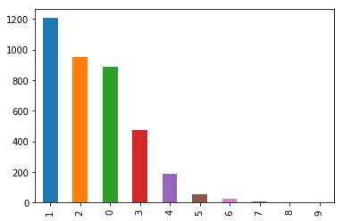

```python
tmp = Y_home.value_counts().plot.bar()
std = Y_home.std()
mean = Y_home.mean()
print('std: %.3f, mean: %.3f' % (std, mean))
```

#### Plot of away team goal counts:

```
std: 1.119, mean: 1.120
```

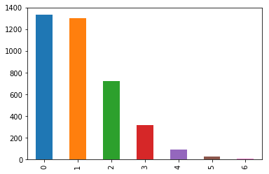

```python
tmp = Y_away.value_counts().plot.bar()
std = Y_away.std()
mean = Y_away.mean()
print('std: %.3f, mean: %.3f' % (std, mean))
```

#### Plot of match result counts:

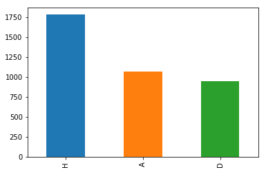

```python
Y_wl.value_counts().plot.bar()
```

## Feature Importance Analysis

We plotted the feature importance of both the home team goals and away team goals. In both plots, we observe that B365 betting odds are the most salient features, suggesting that their betting odds contain very useful information for predicting outcomes of the matches.

Another interesting observation is we can see which team is a useful information for predicting goals. For example, Aston Villa is one of the top feature for predicting home team goals, which means they might tend to score many goals when they play home games. Away team everton is also a top feature in this case, which suggests they tend to concede many goals when playing away teams.

#### feature importance for predicting home team goals:

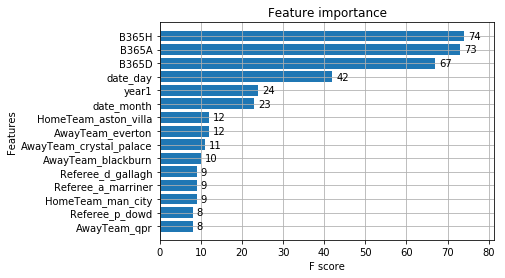

```python
xgb.plot_importance(model, height=0.8, max_num_features=15)
```

#### feature importance for predicting away team goals:

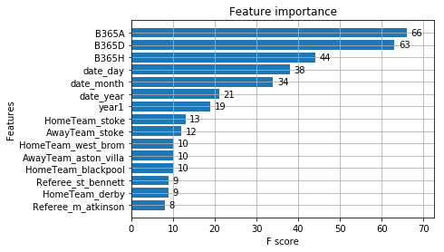

```python
xgb.plot_importance(model, height=0.8, max_num_features=15)
```

# Feature Engineering - Betting Odds

```python
import warnings
warnings.filterwarnings('ignore')
# Imports
import pandas as pd
import math
import numpy as np
from sklearn.model_selection import cross_val_score
from xgboost.sklearn import XGBRegressor, XGBClassifier
import xgboost as xgb
import time
import string

from sklearn.linear_model import LogisticRegression
from sklearn import metrics
from sklearn.model_selection import train_test_split
from sklearn import preprocessing

from sklearn.preprocessing import Imputer

from sklearn.ensemble import RandomForestClassifier

from sklearn import tree

import pandas as pd
import matplotlib.pyplot as plt
import seaborn as sns

raw_train = pd.read_csv('soccer_combined_after05.csv')

Y_home = raw_train['FTHG']
Y_away = raw_train['FTAG']
Y_wl = raw_train['FTR']

X = raw_train.drop(['FTHG', 'FTAG', 'FTR', 'HTHG', 'HTAG', 'HTR',
                    'HS', 'AS', 'HST', 'AST', 'HHW', 'AHW', 'HC', 'AC',
                    'HF', 'AF', 'HO', 'AO', 'HY', 'AY', 'HR', 'AR',
                    'HBP', 'ABP'], axis=1, errors='ignore')

X = process_data(X, drop_odds=False)

all_odds = ['B365A', 'B365D', 'B365H',
            'BSA', 'BSD', 'BSH',
            'BWA', 'BWD', 'BWH',
            'GBA', 'GBD', 'GBH',
            'IWA', 'IWD', 'IWH',
            'LBA', 'LBD', 'LBH',
            'PSA', 'PSD', 'PSH',
            'SBA', 'SBD', 'SBH',
            'SJA', 'SJD', 'SJH',
            'VCA', 'VCD', 'VCH',
            'WHA', 'WHD', 'WHH']
odds = all_odds

X_odds = raw_train[all_odds]

# Map Y_wl (win or loss) to numerical values.
Y_wl_num = Y_wl.replace({'A':-1, 'D':0, 'H':1})
data_odds_wl = pd.concat([X_odds, Y_wl_num], axis=1)

# Separate X_odds into Home, Away, and Draw; combine each of them them with the numerical representation of the game.
X_odds_home = X_odds.filter(regex = ".*H$")
X_odds_away = X_odds.filter(regex = ".*A$")
X_odds_draw = X_odds.filter(regex = ".*D$")
```

#### A Sample: Taking a Glimpse of bets and results

```python
Chelsea_v_Arsenal = raw_train[['HomeTeam','AwayTeam','year','FTR']+odds][(raw_train.HomeTeam =='Chelsea') & (raw_train.AwayTeam == 'Arsenal')]
Arsenal_v_Chelsea = raw_train[['HomeTeam','AwayTeam','year','FTR']+odds][(raw_train.HomeTeam =='Arsenal') & (raw_train.AwayTeam == 'Chelsea')]
```

```python
Chelsea_v_Arsenal.head()
```

|  | HomeTeam | AwayTeam | year | FTR | B365A | B365D | B365H | BSA | BSD | BSH | ... | SBH | SJA | SJD | SJH | VCA | VCD | VCH | WHA | WHD | WHH |
| --- | --- | --- | --- | --- | --- | --- | --- | --- | --- | --- | --- | --- | --- | --- | --- | --- | --- | --- | --- | --- | --- |
| 19 | Chelsea | Arsenal | 2005-2006 | H | 3.75 | 3.2 | 2.00 | NaN | NaN | NaN | ... | 1.909 | 3.40 | 3.25 | 2.00 | 3.75 | 3.20 | 2.00 | 3.75 | 3.2 | 1.83 |
| 545 | Chelsea | Arsenal | 2006-2007 | D | 5.00 | 3.4 | 1.72 | NaN | NaN | NaN | ... | 1.670 | 4.33 | 3.40 | 1.73 | 5.00 | 3.40 | 1.70 | 4.50 | 3.1 | 1.72 |
| 1068 | Chelsea | Arsenal | 2007-2008 | H | 3.50 | 3.2 | 2.20 | 3.2 | 3.2 | 2.20 | ... | 2.200 | 3.20 | 3.20 | 2.10 | 3.50 | 3.25 | 2.25 | 3.20 | 3.0 | 2.10 |
| 1284 | Chelsea | Arsenal | 2008-2009 | A | 5.00 | 3.4 | 1.80 | 5.5 | 3.4 | 1.73 | ... | 1.700 | 5.00 | 3.50 | 1.73 | 5.00 | 3.50 | 1.73 | 4.50 | 3.3 | 1.67 |
| 1761 | Chelsea | Arsenal | 2009-2010 | H | 4.50 | 3.6 | 1.80 | 5.0 | 3.4 | 1.75 | ... | 1.700 | 5.00 | 3.50 | 1.73 | 4.75 | 3.50 | 1.83 | 4.80 | 3.3 | 1.80 |

5 rows × 37 columns

```python
Arsenal_v_Chelsea.head()
```

|  | HomeTeam | AwayTeam | year | FTR | B365A | B365D | B365H | BSA | BSD | BSH | ... | SBH | SJA | SJD | SJH | VCA | VCD | VCH | WHA | WHD | WHH |
| --- | --- | --- | --- | --- | --- | --- | --- | --- | --- | --- | --- | --- | --- | --- | --- | --- | --- | --- | --- | --- | --- |
| 165 | Arsenal | Chelsea | 2005-2006 | A | 2.5 | 3.10 | 2.87 | NaN | NaN | NaN | ... | 2.88 | 2.38 | 3.2 | 2.75 | 2.35 | 3.20 | 2.90 | 2.25 | 2.87 | 3.00 |
| 746 | Arsenal | Chelsea | 2006-2007 | D | 2.5 | 3.25 | 2.70 | NaN | NaN | NaN | ... | 2.75 | 2.60 | 3.2 | 2.50 | 2.40 | 3.25 | 2.75 | 2.30 | 3.30 | 2.60 |
| 927 | Arsenal | Chelsea | 2007-2008 | H | 3.1 | 3.00 | 2.50 | 3.0 | 3.1 | 2.3 | ... | 2.40 | 3.00 | 3.2 | 2.25 | 3.00 | 3.20 | 2.30 | 2.88 | 3.00 | 2.25 |
| 1496 | Arsenal | Chelsea | 2008-2009 | A | 2.8 | 3.25 | 2.60 | 2.8 | 3.2 | 2.6 | ... | 2.50 | 2.70 | 3.2 | 2.63 | 2.70 | 3.10 | 2.60 | 2.70 | 3.20 | 2.62 |
| 1656 | Arsenal | Chelsea | 2009-2010 | A | 2.7 | 3.20 | 2.70 | 2.7 | 3.2 | 2.7 | ... | 2.50 | 2.63 | 3.4 | 2.60 | 2.75 | 3.25 | 2.50 | 2.70 | 3.20 | 2.62 |

5 rows × 37 columns

#### Investigate relationship between Bets and Results

While a subset of bookmakers appear to give the same odds, we cannot draw any generalized insights by simply looking at the raw odds.

Essentially, betting odds are public opinions of match outcomes, with participants voting by their cash. As the result, we can calculate the implied probabilities of each game given the odds. Let's see whether we can discover any trend from the implied probabilities.

#### Correlation among odds

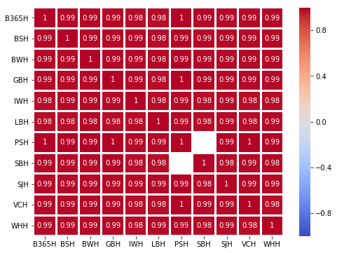

```python
# Plot Heatmaps of correlations!
# Home

plt.figure(figsize=(8,6))
home_corr = X_odds_home.corr()
sns.heatmap(home_corr, annot=True, linecolor='w',linewidth=2, cmap="coolwarm", vmin=-1, vmax=1)
```

The raw odds for among bookmakers are highly correlated. We only showed the correlation among Home odds, but the result is the same for Draw and Away.

#### Implied Probability given Odds:

Notice, different combinations of odds may produce the same implied probabilities. For example, let's say booker A offers 2.0 for Home, Away, and Draw, indicating implied probabilities of 1/3 for each outcome. Booker B offers 3.0 for each of the three outcomes, also ending with implied probabilities of 1/3.

Because the magnitude of raw odds varies, it is quite difficult to visualize them. Therefore, we decide to look into implied probabilities, since they are essentially normalized odds.

```python
# calculate implied probabilities: sample data = Chelsea_v_Arsenal
basic_info = ['HomeTeam','AwayTeam','year','FTR']
```

```python
# Extract all inplied probabilities from the table
# 1. group by the same companies
# 2. compute the tuple of probabilities
# 3. return the new table

# input: row = [A,D,H, A,D,H, A,D,H,...] in odds form
# output row in normalized probability form
def implied_prob_row(row):
    assert(len(row) % 3 == 0)
    prob = []
    idx = row.index.map(lambda x: x[:-1]).unique()
    for i in idx:
        prob_temp = []
        cur_odds = row[[i+'A', i+'D', i+'H']]
        if close(sum(cur_odds), 1):
            print('Already Normalized')
            return row
        if cur_odds[0] == np.nan:
            prob += cur_odds
            continue
        for o in cur_odds:
            prob_temp.append(1.0/o)

        prob += (normalize(prob_temp))
    return pd.Series(prob, index=row.index)

def normalize(L):
    tot = sum(L)
    return [i/tot for i in L]

def close(x,y):
    return abs(x-y) < 0.000000001
```

```python
X_full_odds = raw_train[odds]

X_odds_home = X_full_odds[odds].filter(regex='.*H$')
X_odds_away = X_full_odds[odds].filter(regex='.*A$')
X_odds_draw = X_full_odds[odds].filter(regex='.*D')

X_implied_prob = X_full_odds.apply(implied_prob_row, axis=1)
```

```
Text(0.5,1,'Odds')
```

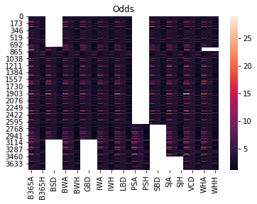

```python
sns.heatmap(raw_train[odds]);
plt.title('Odds')
```

```
Text(0.5,1,'Implied Probability')
```

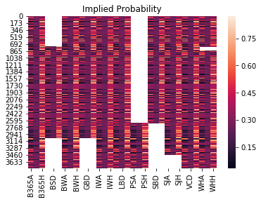

```python
sns.heatmap(X_implied_prob);
plt.title('Implied Probability')
```

As presented by above heatmaps, implied probability is a more normalized measure for bookmakers' believe in the match outcomes.

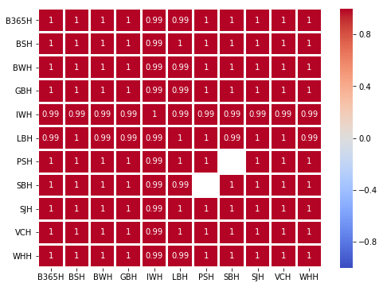

```python
X_implied_prob_home = X_implied_prob.filter(regex = ".*H$")
home_corr = X_implied_prob_home.corr()
plt.figure(figsize=(8,6))
sns.heatmap(home_corr, annot=True, linecolor='w',linewidth=2, cmap="coolwarm", vmin=-1, vmax=1)
```

After converting the odds to implied probability, the correlations among bookmakers became even higher for Home odds. Again, this trend also applies to Aways and Draws.

## How often do Bookmakers' predictions match game outcomes

```python
# Computer booker_prediction base on odds
def compute_booker_pred(row):
    assert(len(row) % 3 == 0)
    pred = []
    idx = row.index.map(lambda x: x[:-1]).unique()
    for i in idx:
        cur_odds = row[[i+'A', i+'D', i+'H']]
        if cur_odds[0] == np.nan:
            prob.append(np.nan)
            continue
        else:
            pred.append(str(np.argmin(cur_odds))[-1])
    return pd.Series(pred, index=idx+'pred')

X_full_odds = raw_train[odds]
Booker_pred = X_full_odds[odds].dropna(axis=1).apply(compute_booker_pred, axis=1)
X_full_odds = pd.concat([X_full_odds, Booker_pred], axis=1)

for col in X_full_odds.columns:
    if "pred" in col:
        print(col+' matching rate: ', np.sum(X_full_odds[col]==raw_train.FTR).astype(int)/len(X_full_odds[col]))
```

```
B365pred matching rate:  0.546578947368421
BWpred matching rate:  0.5455263157894736
VCpred matching rate:  0.5452631578947369
```

For this analysis, we removed all data with missing value because it would distort the accuracy. Because the bookmakers tend to have extremely close, if not the same, implied probabilities, their matching rate should be same, which is exactly shown in the computations above.

The accuracy of bookmakers are not very promising. As it turns out, the most likely match outcomes predicted by bookies are always Home or Away, but never Draw. However, more nearly 1/4 of the games ended in draws.

We looked into the differences in match rate. The discrepencies are due to the fact that many bookmakers have incomplete data. The output predictions between companies are nearly identical. Therefore, we decided to use B365 for later analysis, becuase:

[output not shown]

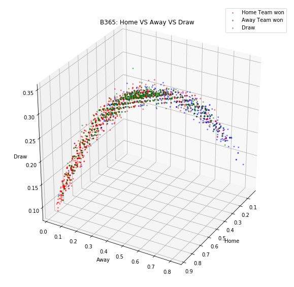

```python
from mpl_toolkits.mplot3d import Axes3D

fig = plt.figure(figsize=(10,10))
ax  = fig.add_subplot(111,projection ="3d")

result = [('r','H','Home Team won'), ('b', 'A', 'Away Team won'), ('g', 'D', 'Draw')]
for c,r,l in result:
    ax.scatter(X_implied_prob[raw_train.FTR == r]["B365H"],X_implied_prob[raw_train.FTR == r]["B365A"],X_implied_prob[raw_train.FTR == r]["B365D"],alpha=.4,linewidth =1,c = c, s=4, label=l)

ax.set_xlabel("Home")
ax.set_ylabel("Away")
ax.set_zlabel("Draw")
plt.title("B365: Home VS Away VS Draw")
#plt.show()
plt.legend()

ax.view_init(30, 30)
plt.draw()
```

The above graph showed the implied probabilities from B365 odds, colored by the match outcomes. As we can observe, there is no clear boundaries among colors and most of them are mixed in the middle. This contributes to the low accracy of bookmakers' predications mentioned above.

# Can we design some strategies to profit off the predictions?

#### Strategies

```
* Bet along bookmakers' predictions
* Bet against bookmakers' predictions
* Bet according to the Logistic Regression model
```

How would our return look like?

Notice, we obtain different returns by betting with different bookers. If we bet with booker A, in order to get 100 dollars back regardless of any outcome, we need to place 50 for each of the actions, meaning we need to pay 150 to guarantee a 100 return. On the other hand, by doing business with booker B, we are guaranteed a 100 return by betting 33.33 in all three actions.

As the result, choosing a good bookie is significant to our expected return!

For this analysis, we decided to use B365 data for three reasons:

[output not shown]

```python
X_full_odds.head()

# rename the implied probability df to X_full_implied_prob
# name the df with betting odds X_full_odds
X_full_implied_prob = X_full_odds
X_full_odds = raw_train[basic_info + odds]
B365 = X_full_odds[basic_info+['B365H', 'B365A', 'B365D']]
B365.head()
```

|  | HomeTeam | AwayTeam | year | FTR | B365H | B365A | B365D |
| --- | --- | --- | --- | --- | --- | --- | --- |
| 0 | Aston Villa | Bolton | 2005-2006 | D | 2.30 | 3.00 | 3.25 |
| 1 | Everton | Man United | 2005-2006 | A | 5.00 | 1.72 | 3.40 |
| 2 | Fulham | Birmingham | 2005-2006 | D | 2.37 | 2.87 | 3.25 |
| 3 | Man City | West Brom | 2005-2006 | D | 1.72 | 5.00 | 3.40 |
| 4 | Middlesbrough | Liverpool | 2005-2006 | D | 2.87 | 2.40 | 3.20 |

### Strategy One: simply follow the booker's prediction

```python
# bookers = ['VC', 'SJ', 'BW', 'IW', 'LB', 'PS', 'GB', 'BS', 'B365', 'SB', 'WH']
bookers = list(set(map(lambda x: x[:-1], odds)))
bet_size = 100

############################################################
#            strategies
############################################################

def contrarian_strategy(row):
    pred = []
    idx = row.index.map(lambda x: x[:-1]).unique()
    for i in idx:
        cur_odds = row[[i+'A', i+'D', i+'H']]
        if cur_odds[0] == np.nan:
            prob.append(np.nan)
            continue
        else:
            # argmax here is the strategy!
            pred.append(str(np.argmax(cur_odds))[-1])
    return pd.Series(pred, index=idx+'pred')

def compute_booker_pred(row):
    #assert(len(row) % 3 == 0)
    pred = []
    idx = row.index.map(lambda x: x[:-1]).unique()
    for i in idx:
        cur_odds = row[[i+'A', i+'D', i+'H']]
        if cur_odds[0] == np.nan:
            prob.append(np.nan)
            continue
        else:
            pred.append(str(np.argmin(cur_odds))[-1])
    return pd.Series(pred, index=idx+'pred')

############################################################

def compute_bet_return(row):
    # will break the info into bins: each bin contains ['H', 'A', 'D', 'pred']
    returns = []
    #idx = bookers
    idx = row.index.map(lambda x: x[:-1]).unique().intersection(bookers)
    return_idx = []

    for i in idx:
        cur_pred = row[i+'pred']
        cur_odds = row[[i+'A', i+'D', i+'H']]
        return_idx.append(i+'_ret')
        if row[i+'H'] == np.nan:
            returns.append(np.nan)
        elif cur_pred == row['FTR']:
            returns.append(bet_size * cur_odds[i+cur_pred])
        else:
            returns.append(0)

    return pd.Series(returns, index = return_idx)

############################################################
#            Wrapper
############################################################

def strategy_return(row):
    cur_odds = row[['B365A', 'B365D', 'B365H']]
    return bet_size * cur_odds['B365'+row['strategy_pred']]*(row['strategy_pred'] == row['FTR'])

def compute_custom_strategy_ret(data, strategy_pred, bet_size):
    # just use B365 odds for this!
    # apply strategy
    data['strategy_pred'] = strategy_pred
    print(data.iloc[:5])
    data['strategy_ret'] = data.apply(strategy_return, axis=1)
    data['bet_size'] = bet_size
    performance = data[['bet_size', 'strategy_ret']].sum()
    return (performance)
```

```python
B365_follow_booker = B365
B365_follow_booker['B365pred'] = B365_follow_booker.filter(regex='^B365').apply(compute_booker_pred, axis=1)
B365_follow_booker.head()
B365_follow_booker['B365_ret'] = B365.apply(compute_bet_return, axis=1)
B365_follow_booker['bet_size'] = bet_size
```

```python
B365_follow_booker.head()
```

|  | HomeTeam | AwayTeam | year | FTR | B365H | B365A | B365D | B365pred | B365_ret | bet_size |
| --- | --- | --- | --- | --- | --- | --- | --- | --- | --- | --- |
| 0 | Aston Villa | Bolton | 2005-2006 | D | 2.30 | 3.00 | 3.25 | H | 0.0 | 100 |
| 1 | Everton | Man United | 2005-2006 | A | 5.00 | 1.72 | 3.40 | A | 172.0 | 100 |
| 2 | Fulham | Birmingham | 2005-2006 | D | 2.37 | 2.87 | 3.25 | H | 0.0 | 100 |
| 3 | Man City | West Brom | 2005-2006 | D | 1.72 | 5.00 | 3.40 | H | 0.0 | 100 |
| 4 | Middlesbrough | Liverpool | 2005-2006 | D | 2.87 | 2.40 | 3.20 | A | 0.0 | 100 |

```python
print('return by following Booker preds')
print(B365_follow_booker[['bet_size', 'B365_ret']].sum())
print('strategy return :', B365_follow_booker[['bet_size', 'B365_ret']].sum().pct_change().iloc[1])
```

```
return by following Booker preds
bet_size    380000.0
B365_ret    371465.0
dtype: float64
strategy return : -0.02246052631578943
```

### The Contratian Strategy on B365

```python
B365_contrarian = B365
```

```python
B365_contrarian['B365pred'] = B365_contrarian[['B365H','B365D','B365A']].apply(contrarian_strategy, axis=1)
B365_contrarian['B365_ret'] = B365_contrarian.apply(compute_bet_return, axis=1)
B365_contrarian['bet_size'] = bet_size
B365_contrarian.head()
```

|  | HomeTeam | AwayTeam | year | FTR | B365H | B365A | B365D | B365pred | B365_ret | bet_size |
| --- | --- | --- | --- | --- | --- | --- | --- | --- | --- | --- |
| 0 | Aston Villa | Bolton | 2005-2006 | D | 2.30 | 3.00 | 3.25 | D | 325.0 | 100 |
| 1 | Everton | Man United | 2005-2006 | A | 5.00 | 1.72 | 3.40 | H | 0.0 | 100 |
| 2 | Fulham | Birmingham | 2005-2006 | D | 2.37 | 2.87 | 3.25 | D | 325.0 | 100 |
| 3 | Man City | West Brom | 2005-2006 | D | 1.72 | 5.00 | 3.40 | A | 0.0 | 100 |
| 4 | Middlesbrough | Liverpool | 2005-2006 | D | 2.87 | 2.40 | 3.20 | D | 320.0 | 100 |

```python
print('return by following Contrarian Strategy')

print(B365_contrarian[['bet_size', 'B365_ret']].sum())
print('strategy return :', B365_follow_booker[['bet_size', 'B365_ret']].sum().pct_change().iloc[1])
```

```
return by following Contrarian Strategy
bet_size    380000.0
B365_ret    344176.0
dtype: float64
strategy return : -0.09427368421052629
```

### Logistic Regression Model

```python
############################################################
#            Wrapper
############################################################

def strategy_return(row):
    cur_odds = row[['B365A', 'B365D', 'B365H']]
    return bet_size * cur_odds['B365'+row['strategy_pred']]*(row['strategy_pred'] == row['FTR'])


def compute_custom_strategy_ret(data, strategy_pred, bet_size):
    # just use B365 odds for this!
    # apply strategy
    data['strategy_pred'] = strategy_pred
    data['strategy_ret'] = data.apply(strategy_return, axis=1)
    data['bet_size'] = bet_size
    performance = data[['bet_size', 'strategy_ret']].sum()
    return (performance)

# This is the model we trained previously:

Y_home = raw_train['FTHG']
Y_away = raw_train['FTAG']
Y_wl = raw_train['FTR']

X = raw_train.drop(['FTHG', 'FTAG', 'FTR', 'HTHG', 'HTAG', 'HTR',
                    'HS', 'AS', 'HST', 'AST', 'HHW', 'AHW', 'HC', 'AC',
                    'HF', 'AF', 'HO', 'AO', 'HY', 'AY', 'HR', 'AR',
                    'HBP', 'ABP'], axis=1, errors='ignore')

# X = raw_train.drop(['HTHG', 'HTAG', 'FTHG', 'FTAG', 'FTR', 'HTR'], axis=1, errors='ignore')

X = process_data(X)

K = 5

model = LogisticRegression()
# model = RandomForestClassifier()
# model = tree.DecisionTreeClassifier()
# scores = cross_val_score(model, X, Y_wl, cv=K)
model.fit(X, Y_wl)
Y_lr = model.predict(X)
#print('cross validation accuracy:', np.mean(np.array(scores)))

# Logistic Regression Result
B365_strat = B365;
returns = compute_custom_strategy_ret(B365_strat, Y_lr, 100)
print(returns)
print('strategy return :', returns.pct_change().iloc[1])
```

```
bet_size        380000.0
strategy_ret    393983.0
dtype: float64
strategy return : 0.03679736842105252
```

### Summary: Profitability

To Summarize, our strategies obtained the following results:

```
* Follow the bookie: -0.02246052631578943
* Contrarian: -0.09427368421052629
* Logistic Regression: 0.03679736842105252
```

Unfortunately, none of the strategies we implemented have achieved significant performance, which is not unsurprising. With sports gambling being a very established activity, we expect it would take significant effort to design a profitable strategy.